# Why did she get A while I got D?

Shuo Zhang

July 12,2016

# Introduction

Education is a key factor for achieving a long-term economic progress. Determinants of students’ performance have been the subject of ongoing debate among educators, academics, and policy makers. During the last decades, the Portuguese education level has improved. In the secondary schools, the core classes of Mathematics and Portuguese (the native language) is the most important since they provide fundamental knowledge for the success in the remaining school subjects (e.g. physics or history). The data of student performance in Mathematics and Portuguese holds value information and can be used to improve decision making of parents and schools and optimize student success. Modeling student performance is an important tool for both educators, parents and students, for the reason that it can help a better understanding of this phenomenon and ultimately improve it.

# Dataset description

This data approach student achievement in secondary education of two Portuguese schools. The data attributes include student grades, demographic, social and school related features and it was collected by using school reports and questionnaires. Two datasets are provided regarding the performance in two distinct subjects: Mathematics (mat) and Portuguese language (por). The target is to investigate the contributing factors associated with G3 (the final year grade). At first, the two datasets are merged to one dataset by the same variables.

This data contains 382 observations and 53 variables. The target variables are G3.x (the final year grade of Math) and G3.y (the final year grade in Portuguese). The contributing factors will be presented in 3 categories: school-related (i.e. school extra education support), student-related (i.e. past course performance, age, study time, desire to pursue higher education) and family-related (i.e. parents’ status, quality of family relationship, parents’ education and job). I analyzed most variables and listed the top contributing factors in the following.

# Data Visualization in R

## Which school has better student performance?

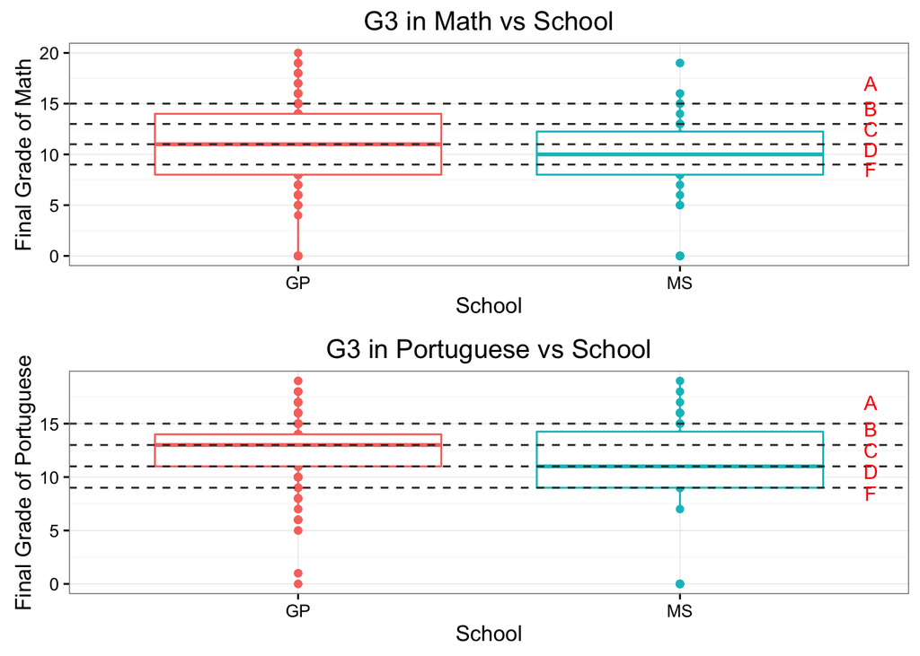

## Does the current student performance have a correlation with the past?

The next question we want to assess is whether G1 and G2 will make significant influence in G3. Let’s take math performance for example.

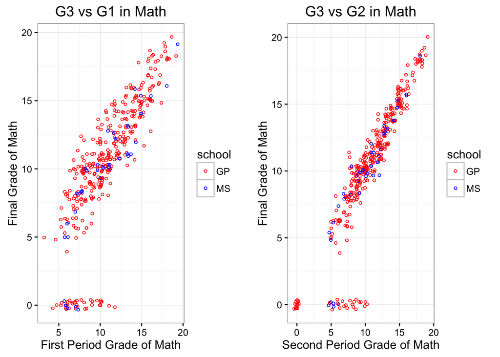

There are a couple interesting facts that show up in their graph. First, we noticed the data trend can be categorize to two relationships: the cluster with 0 grade (students who dropped course) and a strong correlation between G3 and G2, G1 (students who did not drop course ). So the analysis is divided to two parts based on the trend.

### Students who did not drop class:

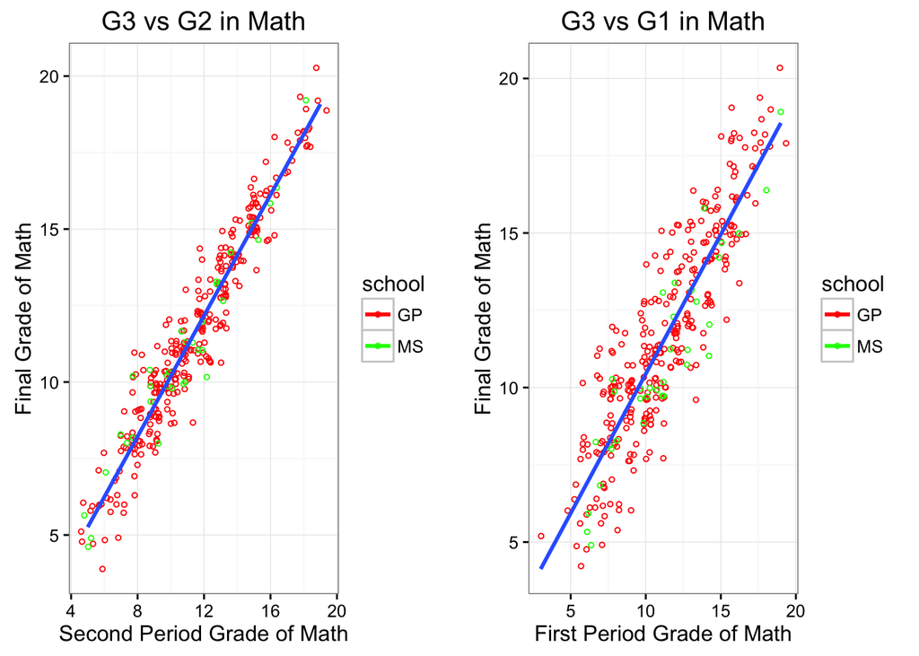

The figure shows linear relationship between the current grade and the past grade, which mean the better you did in the first and second grade, the higher final year grade you would get.

Upon further inspection of the data, it becomes obvious that these cluster with 0 grade most likely belongs to students who dropped the course. There are a couple interesting facts that show up the previous graph. First, it has G1 and/or G2 grades but final grades of 0. Second, there are no G1s of 0 but there are G2s with 0 value.

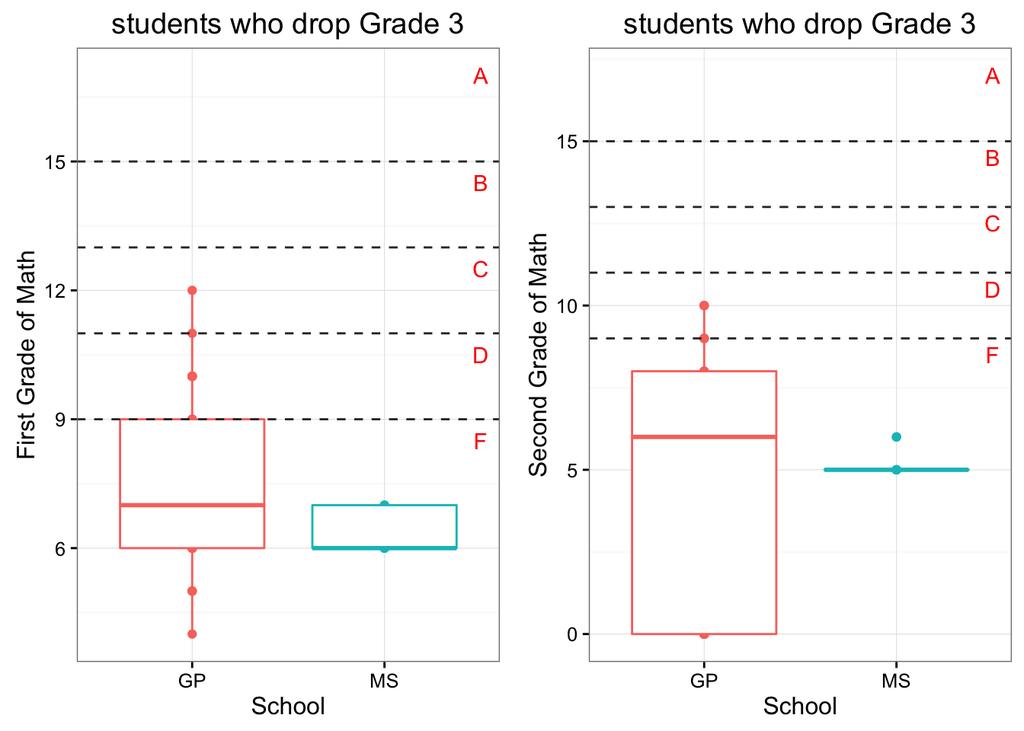

## Does student performance affect by past class failure?

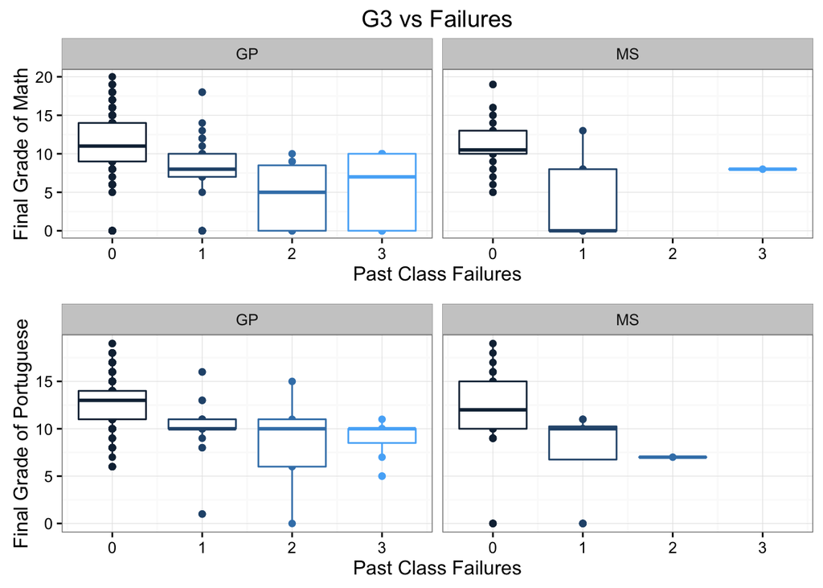

The graph shows the fact that the past class failure play a roles in current student performance, and we can summarize that successful students tend to have a history of success.

## Does student performance change based on age?

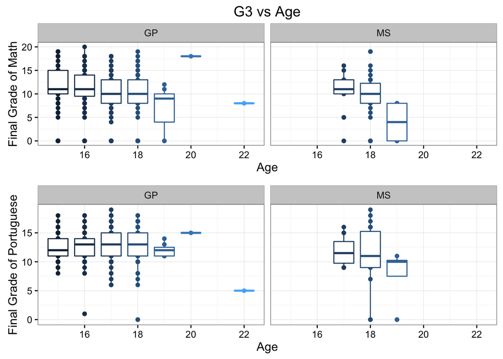

## Does the student who wants to take higher education do better at school?

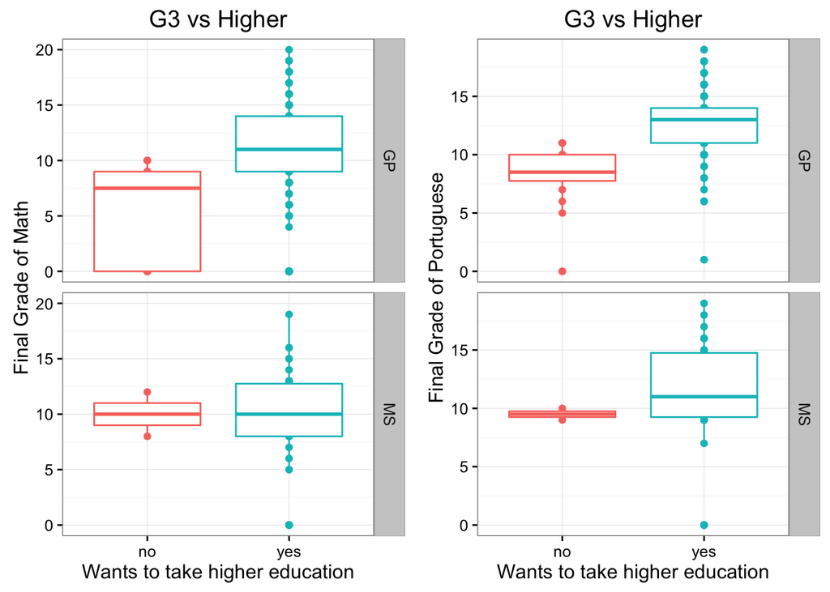

In terms of study motivation, the student with desire to take higher education has a higher probability to achieve success.

## Is the fact true that the more time a student spend on studying, he has higher grade?

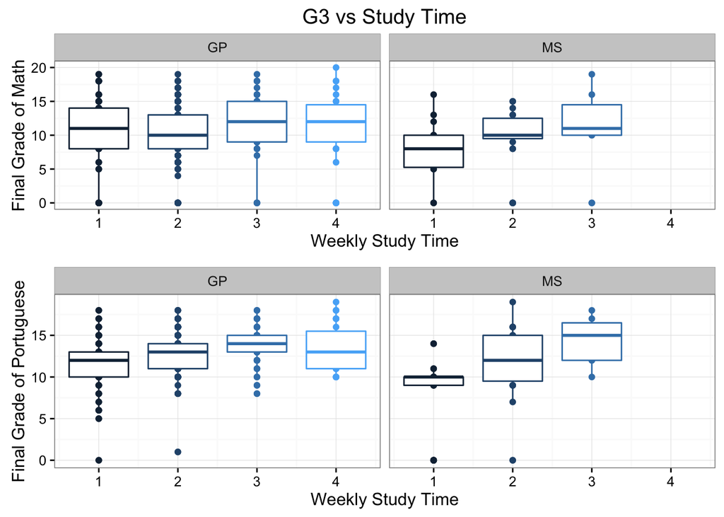

The graph shows a association between study time and the final year grade and the successful students tend to spend more time on course.

## Does absence relate with student performance?

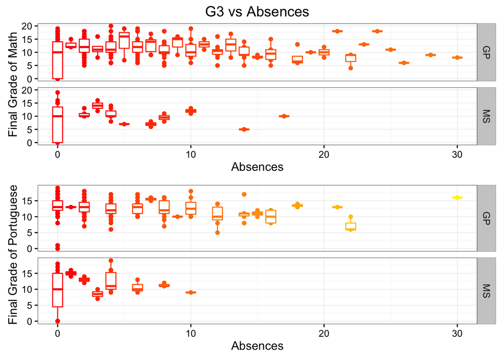

It is hard to conclude a relationship between number of school absences and final year grade. To get a better understanding of the plot, I grouped number of school absences to 4 categories: 0-9, 10-19, 20-29, 30+.

[figure not shown]

## Does the parents’ education and job influence student performance?

let’s take mother’s education and job for example.

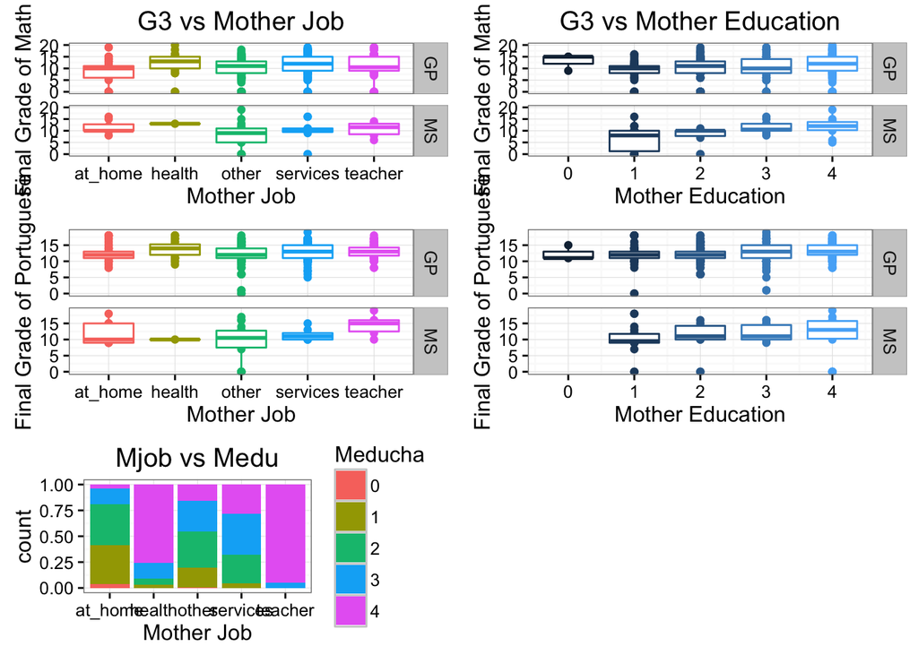

The boxplots at the left of the graph present that the student with working mother incline to have a better course performance that that with home-staying mother. Also upon further investigation of mother job types, the boxplots at the right of the graph demonstrate the student whose mother has a higher education level is most likely to achieve be successful at courses. Furthermore plotting mother’s job with education allows us to understand how the job distribution varies among education levels. Here we see the working mother has a greater portion of higher education level and especially the mother who works as a teacher has the most advanced education degree in average. In conclusion, the student who has a working and well-educated mother tend to be more successful.

# What is the top consideration to choose a school?

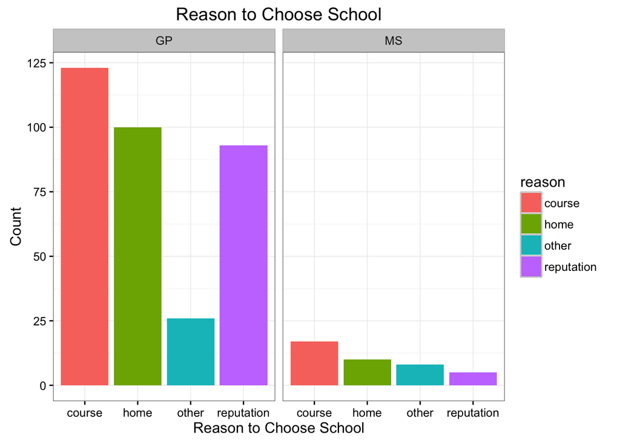

From the graph we can see that the first consideration is the quality of school course and the second is that whether the school is close to home.

# Conclusion